# Section 3: Derivative of Functions of One Variable

Understanding Change and Rate of Change

Calculus Lecture Series

2026-03-05

```r
library(htmltools)

APP_URL <- "https://pchen-aitutor.hf.space"  # ← your Gradio app URL
USER_ID <- "anonymous_user"

browsable(tagList(
  # --- styles (fab, bubble, modal) ---
  tags$style(HTML("
    #tutor-fab{position:fixed;right:20px;bottom:20px;z-index:99999;padding:12px 14px;border-radius:999px;border:1px solid #ddd;background:#fff;box-shadow:0 8px 24px rgba(0,0,0,.15);cursor:pointer;font-weight:600}
    #tutor-fab:hover{background:#f6f8ff}
    #tutor-sel-btn{position:absolute;display:none;z-index:100000;padding:6px 10px;font-size:12px;border:1px solid #e5e7eb;border-radius:10px;background:#111827;color:#f9fafb;box-shadow:0 8px 24px rgba(0,0,0,.2);cursor:pointer;user-select:none}
    #tutor-modal-overlay{display:none;position:fixed;z-index:99998;inset:0;background:rgba(0,0,0,.35)}
    #tutor-modal{position:absolute;top:5%;left:50%;transform:translateX(-50%);width:min(980px,95vw);height:min(720px,90vh);background:#fff;border-radius:10px;box-shadow:0 10px 30px rgba(0,0,0,.25);overflow:hidden}
    #tutor-modal-header{display:flex;justify-content:space-between;align-items:center;padding:10px 14px;background:#f5f5f7;border-bottom:1px solid #e5e5ea;font-weight:600}
    #tutor-close-btn{cursor:pointer;border:none;background:transparent;font-size:18px}
    #tutor-iframe{width:100%;height:calc(100% - 18px);border:0}
  ")),

  # modal + iframe
  tags$div(id="tutor-modal-overlay",
    tags$div(id="tutor-modal",
      tags$div(id="tutor-modal-header","AI Calculus Tutor", tags$button(id="tutor-close-btn","✕")),
      tags$iframe(id="tutor-iframe", src="")
    )
  ),

  # floating button + selection bubble
  tags$button(id="tutor-fab","Ask Tutor"),
  tags$button(id="tutor-sel-btn","Ask Tutor"),

  # script
  tags$script(HTML(sprintf("
    (function(){
      const APP_URL = '%s';
      const USER_ID = '%s';

      function sel(){ try { return (window.getSelection?window.getSelection().toString():'').trim(); } catch(e){ return ''; } }
      function openInline(q, action){
        const p = new URLSearchParams({ user_id: USER_ID, q: q||'', action: action||'prefill' });
        const frame = document.getElementById('tutor-iframe');
        frame.src = APP_URL + '/?' + p.toString();          // Prefill handled by app from URL
        document.getElementById('tutor-modal-overlay').style.display='block';
      }
      function openTab(q, action){
        const p = new URLSearchParams({ user_id: USER_ID, q: q||'', action: action||'prefill' });
        window.open(APP_URL + '/?' + p.toString(), 'ai_tutor_tab', 'noopener');
      }

      // floating button: prefill by default; Alt=send; Ctrl/Cmd=new tab
      document.getElementById('tutor-fab').addEventListener('click', function(ev){
        const q = sel();
        const act = ev.altKey ? 'send' : 'prefill';
        if (ev.ctrlKey || ev.metaKey) openTab(q, act); else openInline(q, act);
      });

      // selection bubble near highlighted text
      const b = document.getElementById('tutor-sel-btn');
      let last='';
      function place(x,y){ b.style.left=(x+10)+'px'; b.style.top=(y+10)+'px'; }
      function show(){ b.style.display='block'; } function hide(){ b.style.display='none'; }
      document.addEventListener('mouseup', e => setTimeout(() => {
        const t = sel(); if (t && t.length>=2 && t.length<=800){ last=t; place(e.pageX,e.pageY); show(); } else hide();
      }, 20));
      window.addEventListener('scroll', hide, {passive:true}); window.addEventListener('resize', hide);

      // bubble click: prefill by default; Alt=send; Ctrl/Cmd=new tab
      b.addEventListener('click', function(ev){
        if (!last) return;
        const act = ev.altKey ? 'send' : 'prefill';
        if (ev.ctrlKey || ev.metaKey) openTab(last, act); else openInline(last, act);
        hide();
      });

      // close modal
      const overlay = document.getElementById('tutor-modal-overlay');
      document.getElementById('tutor-close-btn').addEventListener('click', () => overlay.style.display='none');
      overlay.addEventListener('click', e => { if (e.target===overlay) overlay.style.display='none'; });
    })();
  ", APP_URL, USER_ID)))
))
```

AI Calculus Tutor

[interactive chart not shown]

# Learning Objectives

By the end of this section, students will be able to:

1. **Understand limits** of sequences and functions as the foundation of calculus
2. **Calculate rates of change** and from average rate of change to instantaneous rate of change
3. **Master differentiation rules** for computing derivatives efficiently
4. **Application of derivatives** in solving equations and identifying local maxima and minima

R skills

1. Differentiate functions numerically using R
2. Draw tangent of a function at a given point
3. Solve equations numerically by Newton’s method
4. Solve univariable optimisation problem using R `optimize()`

# Understanding Change

Change is constant—stock prices shift, populations grow, and systems evolve. Calculus, through derivatives, gives us the tools to measure and analyze these rates of change precisely. Whether it’s maximizing profit in production, minimizing stress in engineering, analyzing demand in economics, or modeling motion in physics, derivatives offer a unified mathematical approach to understanding change.

# Knowledge Point 1: Limits of Sequences and Limits of Functions

## The Foundation of Calculus

Before we can understand derivatives, we must grasp the concept of limits—the mathematical foundation that makes calculus possible. Limits allow us to analyze behavior “at the edge” of what we can directly observe.

### Example 3.0: The Limit of a Sequence

What os the sum of the following series:

$$\frac{1}{2} + \frac{1}{4} + \frac{1}{8}
+ \frac{1}{16} + ...+ + \frac{1}{2^n} + \frac{1}{2^{n+1}}+...$$
Let denote the sum of the first $n$ summands as $S_n$ we have

$$S_n = \frac{1}{2} + \frac{1}{4} +
\frac{1}{8} + \frac{1}{16} + ... + \frac{1}{2^n}$$
Our initial problem becomes:

$$S_n \to ? \hspace{1cm} \mbox{ as
}\hspace{1cm} n \to \infty$$
This problem is formulated as a math problem of limit calculation: there is a function $S_n$ where $n$ is the input variable $S_n$ is output variable.
We are interested in the question to which value the output variable will approach if the input variable approaches a given value. The above formula is often denoted in the following equivalent way:
$$\lim_{n\to \infty}S_n = ?$$

The answer is given in the following graph.

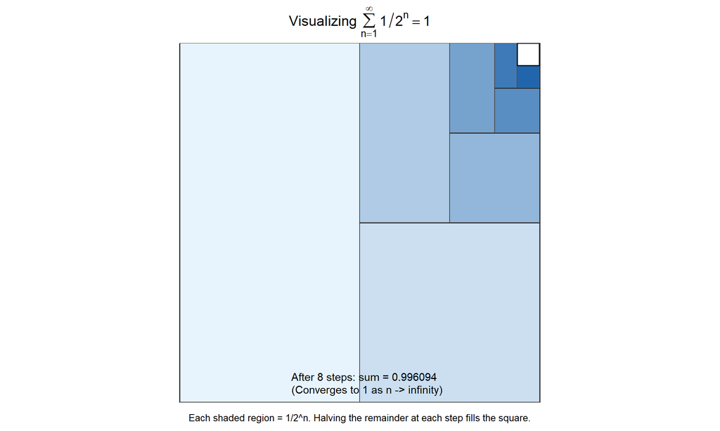

```r
# Visualize the sum 1/2 + 1/4 + 1/8 + ... = 1
# by repeatedly halving a square and shading each portion

# Number of iterations (more = finer approximation to 1)
n <- 8

# Set up plot with square
par(mar = c(2, 2, 3, 2))
plot(NA, xlim = c(0, 1), ylim = c(0, 1), asp = 1,
     xlab = "", ylab = "", main = expression("Visualizing" ~ sum(1/2^n, n==1, infinity) == 1),
     axes = FALSE, xaxs = "i", yaxs = "i")

# Draw the initial square boundary
rect(0, 0, 1, 1, border = "black", lwd = 2)

# Color palette for successive portions (gradient from light to darker)
cols <- colorRampPalette(c("#E8F4FD", "#2166AC"))(n)

# Track the "remaining" rectangle to subdivide: (x0, y0, x1, y1)
remaining <- c(0, 0, 1, 1)
running_sum <- 0

for (i in 1:n) {
  x0 <- remaining[1]
  y0 <- remaining[2]
  x1 <- remaining[3]
  y1 <- remaining[4]

  portion <- 1 / 2^i
  running_sum <- running_sum + portion

  if (i %% 2 == 1) {
    # Odd: vertical cut - take left half, leave right half
    mid_x <- (x0 + x1) / 2
    rect(x0, y0, mid_x, y1, col = cols[i], border = "gray30", lwd = 1)
    # Draw the dividing line
    segments(mid_x, y0, mid_x, y1, col = "black", lwd = 1.5)
    remaining <- c(mid_x, y0, x1, y1)
  } else {
    # Even: horizontal cut - take bottom half, leave top half
    mid_y <- (y0 + y1) / 2
    rect(x0, y0, x1, mid_y, col = cols[i], border = "gray30", lwd = 1)
    # Draw the dividing line
    segments(x0, mid_y, x1, mid_y, col = "black", lwd = 1.5)
    remaining <- c(x0, mid_y, x1, y1)
  }

  # Optional: add label for this portion (can get crowded - comment out if desired)
  # text((x0+remaining[1])/2, (y0+remaining[2])/2, paste0("1/2^", i), cex = 0.6)
}

# Add legend with running sum
legend("bottom",
       legend = c(
         paste0("After ", n, " steps: sum = ", round(running_sum, 6)),
         paste0("(Converges to 1 as n -> infinity)")
       ),
       bty = "n", cex = 0.9)

# Add text annotation
mtext("Each shaded region = 1/2^n. Halving the remainder at each step fills the square.",
      side = 1, line = 0.5, cex = 0.8)
```

### Example 3.1: The Approaching Car

Imagine you’re standing at a bus stop, and you see a car approaching from far away. As time passes, the car gets closer and closer to your position. Even though the car never quite reaches you (it passes by), you can predict exactly where it will be at any given moment.

This scenario illustrates the concept of a **limit**: as the car’s position approaches your location, we can determine its “limiting position” even though it may never actually reach that exact spot.

**Definition 3.1 (Limit of a Function):** We say that the limit of function $f(x)$ as $x$ approaches $a$ is $L$, written as:

$$\lim_{x \to a} f(x) = L$$

if for every $\varepsilon > 0$, there exists a $\delta > 0$ such that whenever $0 < |x - a| < \delta$, we have $|f(x) - L| < \varepsilon$.

**Intuitive Interpretation:** As $x$ gets arbitrarily close to $a$, $f(x)$ gets arbitrarily close to $L$.

### Types of Limits

1. **Two-sided limits:** $\lim_{x \to a} f(x) = L$
2. **Left-hand limits:** $\lim_{x \to a^-} f(x) = L$
3. **Right-hand limits:** $\lim_{x \to a^+} f(x) = L$
4. **Limits at infinity:** $\lim_{x \to \infty} f(x) = L$

**Theorem 3.1 (Existence of Limits):** A limit $\lim_{x \to a} f(x)$ exists if and only if both one-sided limits exist and are equal:
$$\lim_{x \to a^-} f(x) = \lim_{x \to a^+} f(x) =
L$$

### Business Application: Market Saturation

Consider a company’s market share $M(t)$ over time $t$:
$$M(t) =
\frac{50t}{t + 10}$$

As $t \to \infty$, what happens to market share?
$$\lim_{t \to \infty}
\frac{50t}{t + 10} = \lim_{t \to \infty} \frac{50}{1 + \frac{10}{t}} =
50$$

The company’s market share approaches 50% as a long-term limit.

### Four cases of non existence of limits

[interactive chart not shown]

### 1. Basic Algebraic Rules

If $\displaystyle \lim_{x \to a} f(x)$ and $\displaystyle \lim_{x \to a} g(x)$ exist and are finite:

1. **Sum/Difference**
   $$\lim_{x \to a} [f(x) \pm g(x)] = \lim_{x \to a} f(x) \pm \lim_{x \to a}
   g(x)$$
2. **Product**
   $$\lim_{x \to a} [f(x)g(x)] = \left(\lim_{x \to a} f(x)\right) \cdot
   \left(\lim_{x \to a} g(x)\right)$$
3. **Quotient** (denominator limit $\neq 0$)
   $$\lim_{x \to a} \frac{f(x)}{g(x)} = \frac{\lim_{x \to a} f(x)}{\lim_{x
   \to a} g(x)}$$
4. **Constant Multiple**
   $$\lim_{x \to a} [c \cdot f(x)] = c \cdot \lim_{x \to a} f(x)$$
5. **Power** ($n$ positive integer)
   $$\lim_{x \to a} [f(x)]^n = \left(\lim_{x \to a} f(x)\right)^n$$
6. **Root** ($n$ even $\implies$ inside $\ge 0$)
   $$\lim_{x \to a} \sqrt[n]{f(x)} = \sqrt[n]{\lim_{x \to a} f(x)}$$

### 2. Special Limits to Remember

**Polynomials / Rationals:**  
- Direct substitution works if denominator $\neq 0$.  
- For $x \to \infty$, divide numerator & denominator by the highest power of $x$.

**Trigonometric:**
$$\lim_{x \to 0} \frac{\sin x}{x} = 1
\quad\quad
\lim_{x \to 0} \frac{\tan x}{x} = 1$$
$$\lim_{x \to 0} \frac{1 - \cos x}{x} = 0$$

**Exponential / Logarithmic:**
$$\lim_{x \to 0} (1 + x)^{1/x} = e
\quad\quad
\lim_{x \to \infty} \left(1 + \frac{k}{x}\right)^x = e^k$$
$$\lim_{x \to 0} \frac{\ln(1+x)}{x} = 1$$

### 3. Indeterminate Forms & Techniques

**Indeterminate Forms:**  
$\frac{0}{0},\; \frac{\infty}{\infty},\; 0 \cdot \infty,\; \infty - \infty,\; 0^0,\; \infty^0,\; 1^\infty$

**Techniques:**
1. **Factor/Simplify** – cancel common terms.
2. **Multiply by Conjugate** – when square roots appear.
3. **L’Hôpital’s Rule** (for $\frac{0}{0}$ or $\frac{\infty}{\infty}$): (It will become clear later.)
$$\lim_{x \to a} \frac{f(x)}{g(x)} = \lim_{x \to a}
\frac{f'(x)}{g'(x)}$$
if RHS limit exists.
4. **Series Expansion** – use Taylor/Maclaurin expansions.
5. **Substitution** – change variables to simplify behavior.

### Four exercises of calculation of limit with graphs

$$\lim_{x\to1}
\frac{x^2-1}{x-1}=2$$
$$\lim_{x\to
\pm0} f(x)=1 \hspace{2cm} \mbox{with}\hspace{0.5cm}f(x) = \begin{cases}
x + 1 & \text{if } x < 0 \\
2x + 1 & \text{if } 0 \leq 0 \\
\end{cases}$$
$$\lim_{x\to
+\infty}\frac{50x}{x+10}=50$$

$$\lim_{n \to +\infty}
\frac{2n+1}{n+1}=2$$

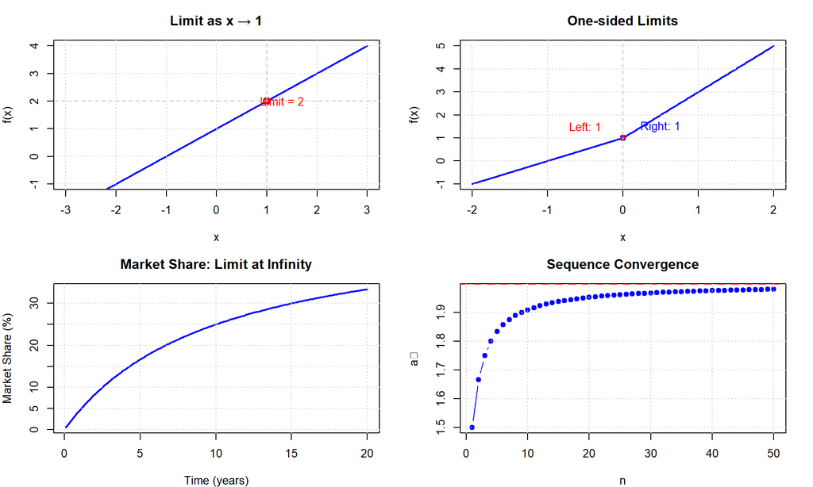

Understanding Limits Through Visualization

```r
par(mfrow = c(2, 2), mar = c(4, 4, 3, 2))

# 1. Basic limit example
x <- seq(-3, 3, by = 0.01)
y <- (x^2 - 1) / (x - 1)
y[x == 1] <- NA  # Remove discontinuity point

plot(x, y, type = "l", lwd = 2, col = "blue",
     main = "Limit as x → 1", xlab = "x", ylab = "f(x)",
     ylim = c(-1, 4))
points(1, 2, col = "red", pch = 19, cex = 1.5)
text(1.3, 2, "Limit = 2", col = "red")
abline(v = 1, col = "gray", lty = 2)
abline(h = 2, col = "gray", lty = 2)
grid()

# 2. One-sided limits
x2 <- seq(-2, 2, by = 0.01)
y2 <- ifelse(x2 < 0, x2 + 1, 2*x2 + 1)

plot(x2, y2, type = "l", lwd = 2, col = "blue",
     main = "One-sided Limits", xlab = "x", ylab = "f(x)")
points(0, 1, col = "red", pch = 19, cex = 1.2)  # Left limit
points(0, 1, col = "blue", pch = 1, cex = 1.2)  # Right limit
text(-0.5, 1.5, "Left: 1", col = "red")
text(0.5, 1.5, "Right: 1", col = "blue")
abline(v = 0, col = "gray", lty = 2)
grid()

# 3. Limit at infinity
x3 <- seq(0.1, 20, by = 0.1)
y3 <- 50*x3 / (x3 + 10)

plot(x3, y3, type = "l", lwd = 2, col = "blue",
     main = "Market Share: Limit at Infinity",
     xlab = "Time (years)", ylab = "Market Share (%)")
abline(h = 50, col = "red", lty = 2, lwd = 2)
text(15, 45, "Limit = 50%", col = "red")
grid()

# 4. Sequence convergence
n <- 1:50
sequence <- (2*n + 1) / (n + 1)

plot(n, sequence, type = "b", pch = 19, col = "blue",
     main = "Sequence Convergence", xlab = "n", ylab = "aₙ")
abline(h = 2, col = "red", lty = 2, lwd = 2)
text(40, 2.1, "Limit = 2", col = "red")
grid()
```

```r
par(mfrow = c(1, 1))
```

### 4. Continuity and Limit

A function $f(x)$ is at the point $x_0$ if
$$\lim_{x \to x_0} f(x) = f(x_0).$$

Geometrically, continuity means that from both the left and the right, the values of $f(x)$ approach the function value at the point $f(x_0)$. Therefore, the function is continuous at that point.

At the point $x = 1$ in the first example above, the function is not continuous because it is not defined at $x = 1$. (However, this can be repaired by defining $f(1) = 2$.)

At the point $x = 0$ in the second example above, $f(x)$ is continuous.

## Interactive Quiz 3.1

# Knowledge Point 2: Rate of Change and Derivatives

## From Average to Instantaneous Change

Understanding how quantities change is fundamental to mathematics, science, and business. While average rates of change tell us about overall trends, **instantaneous rates of change** reveal what’s happening at specific moments.

### Example 3.2: The Speeding Car

Imagine you’re driving on a highway. Your GPS shows that you traveled 120 miles in 2 hours, giving an average speed of 60 mph. But this doesn’t tell the whole story—you might have been stuck in traffic for an hour (0 mph) and then driven 120 mph for the second hour.

The **instantaneous speed** at any moment is what your speedometer shows right now. This is analogous to the **derivative**—the instantaneous rate of change of position with respect to time.

[interactive chart not shown]

**Definition 3.2 (Average Rate of Change):** For a function $f(x)$ over the interval $[a, b]$:
$$\text{Average Rate of Change} = \frac{f(b) -
f(a)}{b - a}$$

**Definition 3.3 (Instantaneous Rate of Change - The Derivative):** The derivative of $f(x)$ at point $x = a$ is:
$$f'(a) = \lim_{h \to 0} \frac{f(a + h) -
f(a)}{h}$$

This represents the **slope of the tangent line** to the curve at point $(a, f(a))$.

### Geometric Interpretation

The derivative has a beautiful geometric interpretation: - **Secant line:** Connects two points on the curve, slope = average rate of change - **Tangent line:** Touches the curve at exactly one point, slope = instantaneous rate of change - **As the two points get closer:** Secant line approaches the tangent line

### Alternative Notations

The derivative can be written in several equivalent ways:
$$f'(x) = \frac{df}{dx} = \frac{d}{dx}f(x) =
Df(x) = \dot{f}(x)$$

### Economic Interpretation: Marginal Analysis

In economics, derivatives represent **marginal** quantities: - **Marginal Cost:** $MC(q) = \frac{dC}{dq}$ (additional cost of producing one more unit) - **Marginal Revenue:** $MR(q) = \frac{dR}{dq}$ (additional revenue from selling one more unit) - **Marginal Profit:** $MP(q) = \frac{d\pi}{dq}$ (additional profit from producing one more unit)

## Interactive Quiz 3.2

# Knowledge Point 3: Calculation of Derivatives (Rules of Differentiation)

## The Toolkit for Computing Derivatives

While the limit definition of derivatives is conceptually important, calculating derivatives using limits for every function would be extremely time-consuming. Fortunately, mathematicians have developed **differentiation rules** that allow us to compute derivatives efficiently.

### Basic Differentiation Rules

**Rule 3.1 (Constant Rule):** $\frac{d}{dx}[c] = 0$ where $c$ is a constant

**Rule 3.2 (Power Rule):** $\frac{d}{dx}[x^n] = nx^{n-1}$ for any real number $n$

**Rule 3.3 (Constant Multiple Rule):** $\frac{d}{dx}[cf(x)] = c \cdot f'(x)$

**Rule 3.4 (Sum/Difference Rule):** $\frac{d}{dx}[f(x) \pm g(x)] = f'(x) \pm g'(x)$

### Advanced Differentiation Rules

**Rule 3.5 (Product Rule):** $\frac{d}{dx}[f(x) \cdot g(x)] = f'(x) \cdot g(x) + f(x) \cdot g'(x)$

**Rule 3.6 (Quotient Rule):** $\frac{d}{dx}\left[\frac{f(x)}{g(x)}\right] = \frac{f'(x) \cdot g(x) - f(x) \cdot g'(x)}{[g(x)]^2}$

**Rule 3.7 (Chain Rule):** $\frac{d}{dx}[f(g(x))] = f'(g(x)) \cdot g'(x)$

### Special Function Derivatives

**Exponential Functions:** - $\frac{d}{dx}[e^x] = e^x$ - $\frac{d}{dx}[a^x] = a^x \ln(a)$

**Logarithmic Functions:** - $\frac{d}{dx}[\ln(x)] = \frac{1}{x}$ - $\frac{d}{dx}[\log_a(x)] = \frac{1}{x \ln(a)}$

**Trigonometric Functions:** - $\frac{d}{dx}[\sin(x)] = \cos(x)$ - $\frac{d}{dx}[\cos(x)] = -\sin(x)$ - $\frac{d}{dx}[\tan(x)] = \sec^2(x)$

## Business Applications

### Example 3.3: Revenue Function

For revenue $R(q) = 100q - 0.5q^2$:
$$R'(q) =
\frac{d}{dq}[100q - 0.5q^2] = 100 - q$$

This is the **marginal revenue** function.

### Example 3.4: Compound Interest

For continuously compounded interest $A(t) = Pe^{rt}$:
$$A'(t) =
\frac{d}{dt}[Pe^{rt}] = Pre^{rt} = rA(t)$$

The growth rate is proportional to the current amount!

### Example 3.5: Production Function (Chain Rule)

For $Q(L) = 100\sqrt{2L + 5} = 100(2L + 5)^{1/2}$:

Using the chain rule:
$$Q'(L) = 100
\cdot \frac{1}{2}(2L + 5)^{-1/2} \cdot 2 = \frac{100}{\sqrt{2L +
5}}$$

## Differentiation using R

As we know, a function can be coded in R. The derivative of the function is itself is also a function and hence the later can also be coded in R. Here is an example of differentiation of a yet to be defined function in R called numerical differentiation.

```r
Derivative_function <- function(f,x,dx=0.000001){
  f_prime <- (f(x+dx)-f(x))/dx
}
```

This R function take function $f$ and real number or sequence $x$ as well as $dx$ as input the output the numerically approximated value of the derivative. It the an approximation because we cannot set R is not calculating the limit of  
$\lim_{dx\to 0} \frac{f(x+dx)-f(x)}{dx}$ but the ratio of $\frac{f(x+dx)-f(x)}{dx}$ for a chosen $dx$.

To see how it works we need to specify a function $f$ as input. Here we use
$$f(x) = 5x-3$$
It is to note that the output of $Derivative\_function$ is not a mathematical formula but the values of the derivative function at $x$.

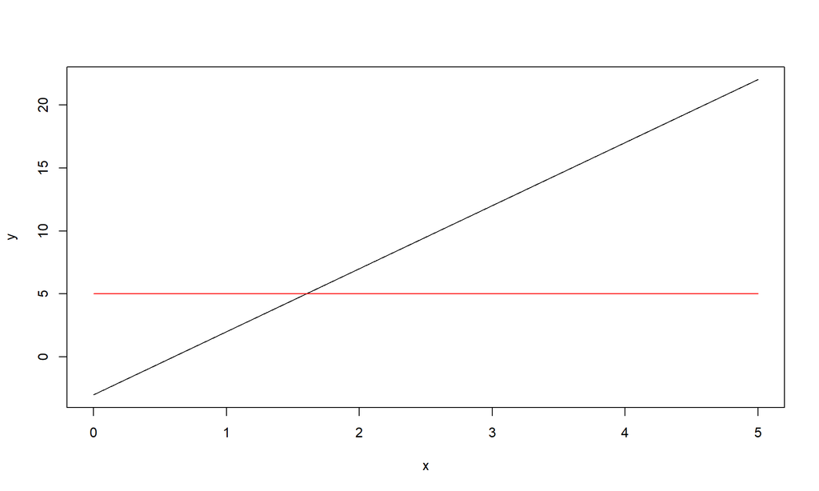

```r
Derivative_function <- function(f,x,dx=0.000001){
  f_prime <- (f(x+dx)-f(x))/dx
}

Linear_function<- function(x) {
  5*x-3
}

x <- seq(0,5,0.001)
dx = 0.00001

y <- Linear_function(x)
f_prime <-Derivative_function(Linear_function,x,dx=0.00001)

### we plot the function y = 5x -3 and its derivative over the interval given by x.
plot(x,y,type="l")
lines(x,f_prime,col="red")
```

Apply Rule 3.2 we have
$$f'(x) =
5$$

Indeed the red line is the derivative $f'(x)=5$.

We look at another example: given a demand function $p = 10 - q$, the revenue $R=p\times q=(10-q)q$ is a quadratic function of $q$. We want to calculate the marginal revenue over the domain $q \in (0,10)$.

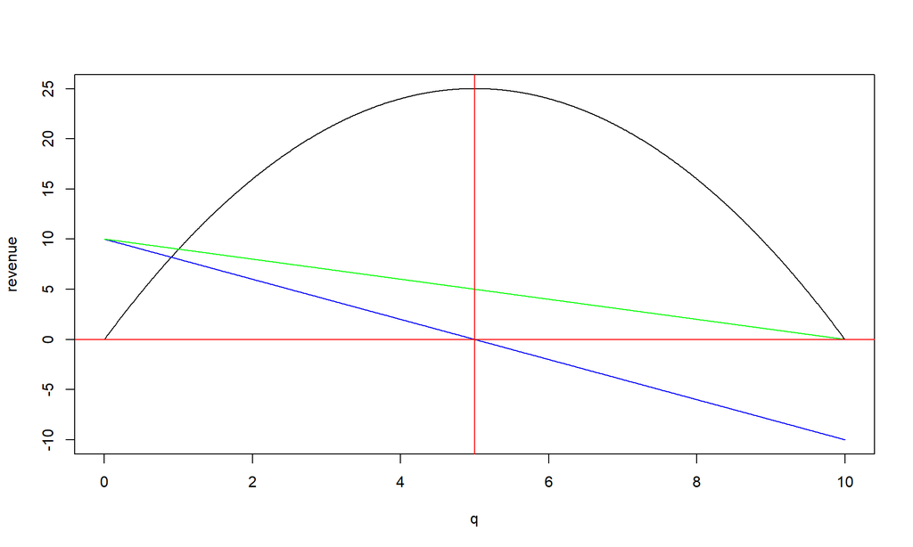

```r
R <- function(q){
  return((10-q)*q)
}

q <- seq(0,10,0.01)

demand <- 10-q

revenue <- R(q)

marginal_revenue <-Derivative_function(R,x=q,dx=0.0000001)

plot(q,revenue,type="l",ylim=c(-10,25))
lines(q,marginal_revenue,col="blue")
lines(q,demand,col="green")
abline(h=0,col="red")
abline(v=5,col="red")
```

Again follow Rule 3.2 we have $R'(q) = 10-2q$. Indeed the blue line is $R'(q)=10 - 2q$.

### Compare the analytic derivative and the numerical derivative

We want to investigate the catalytic derivative of $f(x)=4x^6+2x$ over the domain of (0, 20) and the numerical derivative of $f(x)$ to access how well the the numerical derivative using R approximates the analytic derivative.

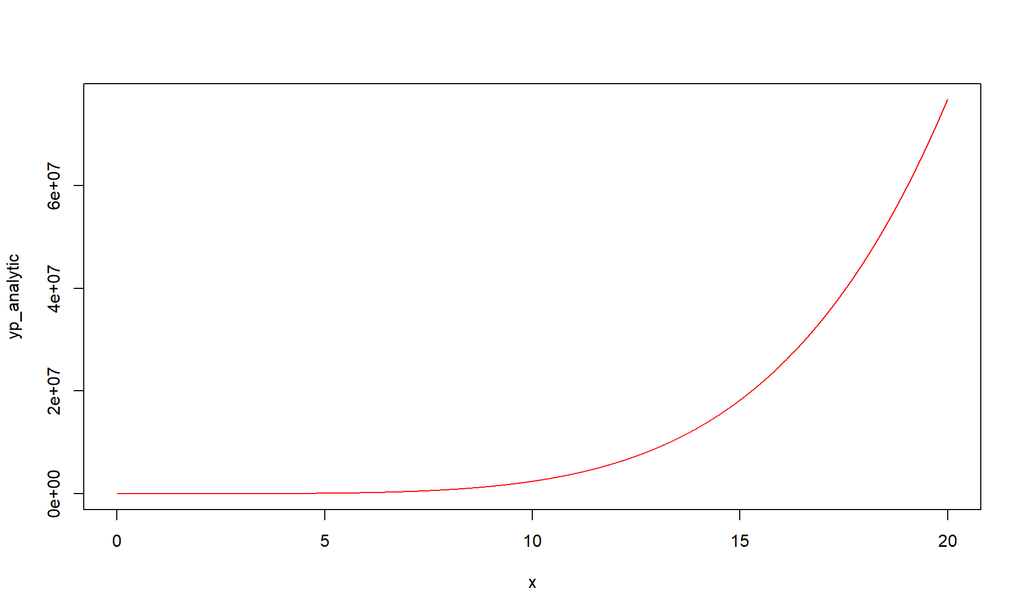

```r
x <- seq(0,20,0.001)

yp_analytic <- 24*x^5+2

F <- function(x){
  4*x^6+2*x
}

yp_numerical <- Derivative_function(F,x,dx=0.0000001)


plot(x,yp_analytic,type="l")

plot(x,yp_analytic,type="l")
lines(x,yp_numerical,col="red")
```

The numerical derivative fits the analytic derivative well.

### Exercise

1. Calculate the derivative of $f(x) = x^3-2x^2-x-10$ analytically and numerically and compare the analytic derivative with the numerical derivative by drawing their curves in the same graph.
2. Draw the graph of $f(x)$ and the tangent at point x= 2. Complete the tasks using following R Environment or using your own local Rstudio.

[interactive chart not shown]

## Interactive Quiz 3.3

# Knowledge Point 4: Application of Derivatives

## 4.1 Newton’s Method for Solving Equations

### Interactive Illustation

**Problem:** Solve $f(x) = 0$ when analytically solutions are difficult.

**Newton’s Method Formula:**

- Starting with $n = 0$, $x_n = x_0$
- repeat
  $$x_{n+1} = x_n -
  \frac{f(x_n)}{f'(x_n)}$$
  $$n <
  n+1$$
  until $|f(x_n)|<\epsilon$

[interactive chart not shown]

### R solution of an equation

```r
# Define the function for which we want to find the root
f <- function(x) {
  return(x^5-x^3+exp(x)-10 )
}





# Newton's method implementation
newton_method2 <- function(f, x0=0,  max_iter = 100) {
  x <- x0
  for (i in 1:max_iter) {
    fx <- f(x)
    x_new <- x - fx / Derivative_function(f,x)
    converge <- abs(x_new-x) <0.0000001
    x <- x_new
  }

  if (converge) {
    return(x)
  } else {
    stop("Newton's method failed to converge")
  }
}



# Find the root
newton_method2(f, x0=2)
```

```
## [1] 1.552487
```

We plot the function around the solution for verification.

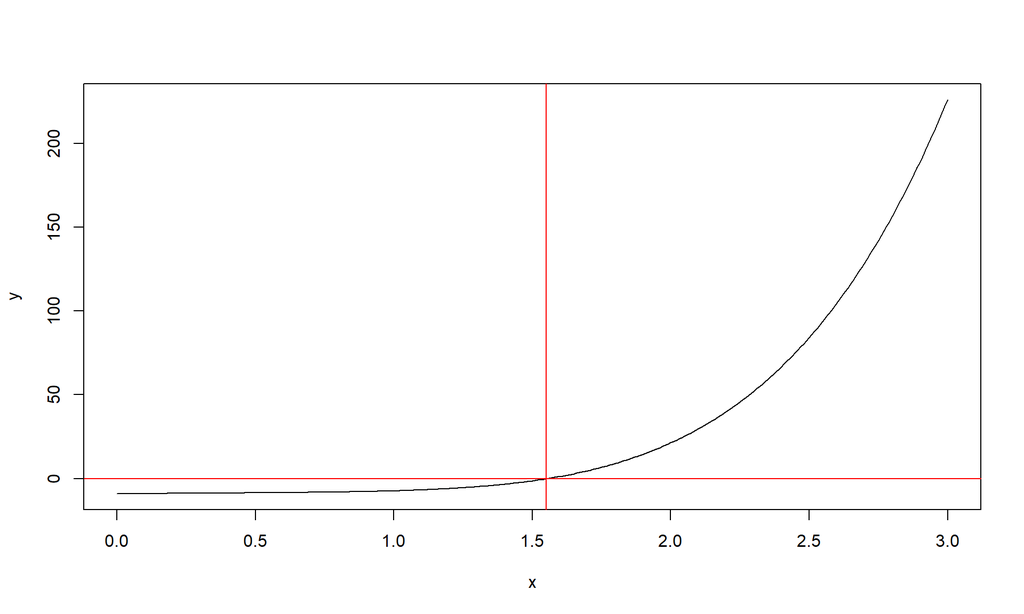

```r
Plot_function <- function(f,x,v0=0) {
  y <- f(x)
  plot(x,y,type="l")
  abline(h=0,col="red")
  abline(v=v0,col="red")
}


x=seq(0,3,0.01)

Plot_function(f,x,v0=1.55)
```

### Exercise

Solve the equation
$$x^5-x^4-102x^3+268x^2+1544x-3360=0$$
by Newton’s method using following R Environment or using your local RStudio.

[interactive chart not shown]

## 4.2 Finding maximum and/or minimum

Often business decisions can be formulated as mathematical maximisation or minimisation problems. The derivative of a function is the most useful tool to identify the maximum and/or minimum of the function.

### Example 3.6: TechOptima’s Optimization Journey

**Business Context:** TechOptima, a rapidly growing data analytics company, faces critical optimization decisions daily. Their CEO, Sarah Chen, reviews three key performance indicators each morning:

- **Revenue Function R(x):** How revenue changes with the number of clients x
- **Cost Function C(x):** How operational costs vary with production volume x
- **Efficiency Function E(x):** How team productivity fluctuates with team size x

Sarah asks her analytics team: *“How do we mathematically identify the optimal points where our metrics are at their best or worst? Where should we focus our resources for maximum impact?”*

This real-world challenge illustrates why understanding the application of derivatives to find local minimum and maximum points is essential for modern business decision-making.

Use the following interactive graph to explore the relation between a maximum/minimum and the tangent at that point. You can change the function under investigation by typing a new function in the input box and click on butoon “Update Function”. Ideally you use a function with many ups and downs.

[interactive chart not shown]

From the exploration in the graph above we come to the following formal presentation.

## Formal Mathematical Presentation

### Critical Points

**Definition 3.4:** A point x = c is called a **critical point** of function f(x) if: 1. f’(c) = 0, OR 2. f’(c) is undefined

Critical points are candidates for local extrema, but not all critical points are extrema.

### Local Extrema

**Local Maximum:** A point x = c where f(c) ≥ f(x) for all x in some open interval containing c.

**Local Minimum:** A point x = c where f(c) ≤ f(x) for all x in some open interval containing c.

**Global Extrema:** The highest (global maximum) or lowest (global minimum) values over the entire domain.

## The First Derivative Test

**Theorem (First Derivative Test):** Let f be continuous at x = c and differentiable on an open interval containing c, except possibly at c itself.

1. **Local Maximum:** If f’(x) changes from positive to negative at x = c
2. **Local Minimum:** If f’(x) changes from negative to positive at x = c
3. **No Extremum:** If f’(x) does not change sign at x = c

## Business Applications

### Application 1: Profit Maximization - TechStart SaaS

**Business Scenario:** TechStart, a Software-as-a-Service company, has determined their monthly profit function based on the number of enterprise clients:

$$P(x) = -2x^2 + 120x - 1000$$

where x is the number of enterprise clients and P(x) is profit in thousands of dollars.

**Solution with pencil and paper**

- Find the critical point

$$P'(x)=-4x+120 =
0\hspace{2cm}\to\hspace{0.5cm} x = 30$$

- The First Derivative Test:

$$P'(x) = -4x + 120 > 0
\hspace{1cm} \mbox{ for } x<30$$

$$P'(x) = -4x + 120 < 0
\hspace{1cm} \mbox{ for } x>30$$

- Conclusion: $X=30$ is the local maximum and the global maximum as well.

### Application 2: Cost Minimization - Manufacturing Efficiency

**Business Scenario:** ManufacturingPlus has analyzed their production costs and found that the average cost per unit follows:

$$C(q) = \frac{10000}{q} + 50 +
q$$

where q is the production quantity and C(q) is the average cost per unit in dollars.

**Solution with pencil and paper**

- Find the critical point

$$C'(q)=-\frac{10000}{q^2}+1 =
0\hspace{2cm}\to\hspace{0.5cm} q = 100$$

- The First Derivative Test:

$$C'(x) = -\frac{10000}{q^2}+1 < 0
\hspace{1cm} \mbox{ for } q < 100$$

$$C'(x) = -\frac{10000}{q^2}+1 > 0
\hspace{1cm} \mbox{ for } q > 100$$

- Conclusion: $q = 100$ is the local minimum and the global minimum as well.

**R solution**

For Application 1

```r
f <- function(x){
  -4*x+120
}

newton_method2(f, x0=3)
```

```
## [1] 30
```

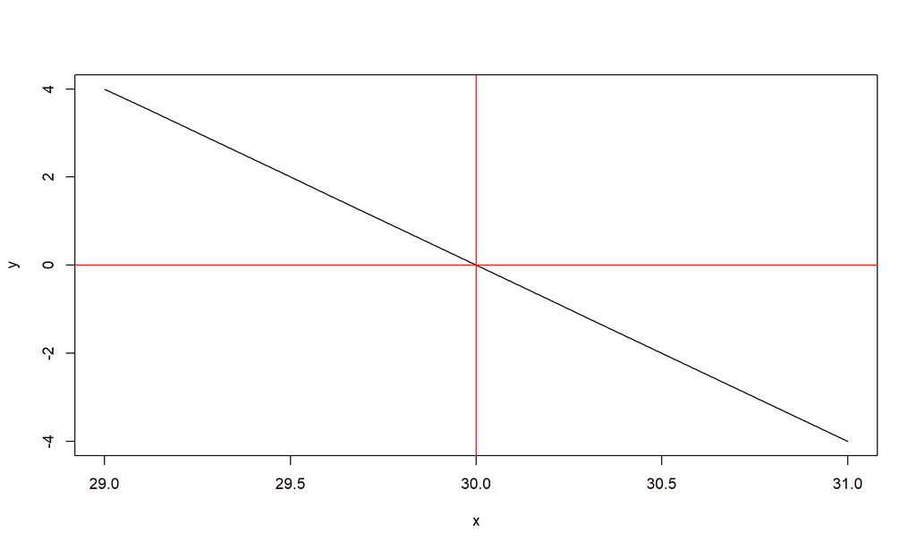

```r
xs<-newton_method2(f, x0=3)

x<-seq(xs-1,xs+1,0.1)
Plot_function(f,x,v0=xs)
```

The graph show the derivative goes from positive to negative. The critical point is a maximum. For Application 2

```r
f <- function(q){
  -10000/q^2+1
}

newton_method2(f, x0=50)
```

```
## [1] 100
```

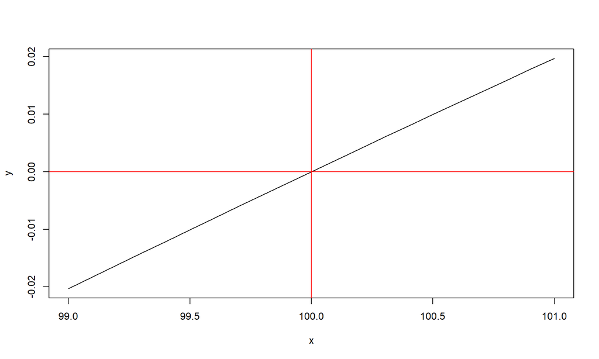

```r
xs<-newton_method2(f, x0=50)

x<-seq(xs-1,xs+1,0.1)
Plot_function(f,x,v0=xs)
```

The graph show the derivative goes from negative to positive. The critical point is a minimum.

### Exercise

Find the critical point of $f(x) = -10x^3+25x+10$ using R. Carry out the first derivative test by drawing the graph of the first derivative around the critical point. Identify whether it is a local maximum o minimum. Complete the task using following R Environment below or in your local RStudio.

[interactive chart not shown]

## Interactive Quiz 3.4

# Comprehensive Review Questions

This section provides review and application questions designed to assess understanding at five different levels. Each level builds upon the previous one, fostering deeper comprehension and the ability to apply concepts in increasingly complex situations.

https://pchen-exercisesfeedbackselect.hf.space

# Summary and Next Steps

This comprehensive Section 3 covers the essential mathematical foundations of differentiation:

1. **Understand limits** of sequences and functions as the foundation of calculus
2. **Calculate rates of change** and from average rate of change to instantaneous rate of change
3. **Apply derivative concepts** to describe real-world phenomena in multiple ways
4. **Master differentiation rules** for computing derivatives efficiently
5. **Application of derivatives** in solving equations and identifying local maxima and minima

**Preparation for Section 4:** These tools provide the foundation for understanding derivatives, which measure rates of change and enable optimization in business contexts.

**Key Takeaways:**

- Differentiation of univariable functions
- Differentiation using R
- Solving equations using Newton’s methods using R
- Find critical points of a function
- Find maximum and minimum of a function using R